Rapport sur l’étude de la ville de Benev-ville

# Bien-être et végétalisation

[interactive table not shown]

## Présentation et analyse

### Introduction

Le projet BENEV vise à identifier les zones prioritaires de revégétalisation dans la ville de Benev-ville. Pour ce faire, nous étudions la perception de nature et son incidence sur le bien-être des résidents en ville. Ce rapport présente les analyses effectuées à partir des données collectées auprès des habitants de Benev-ville.

### Analyse du profil des répondants

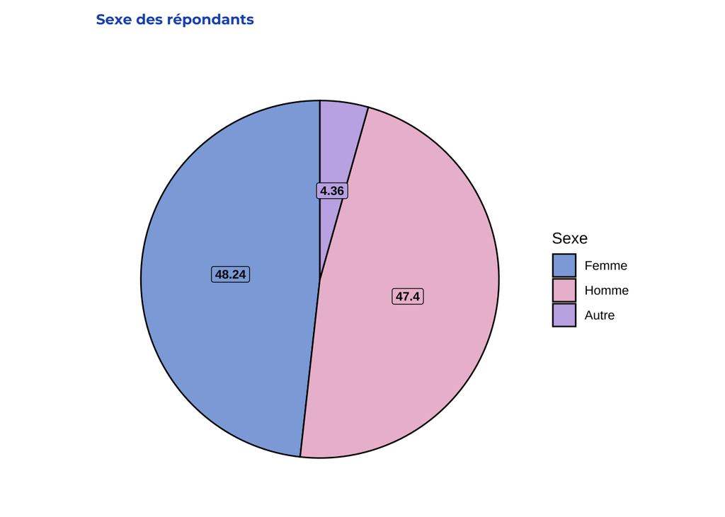

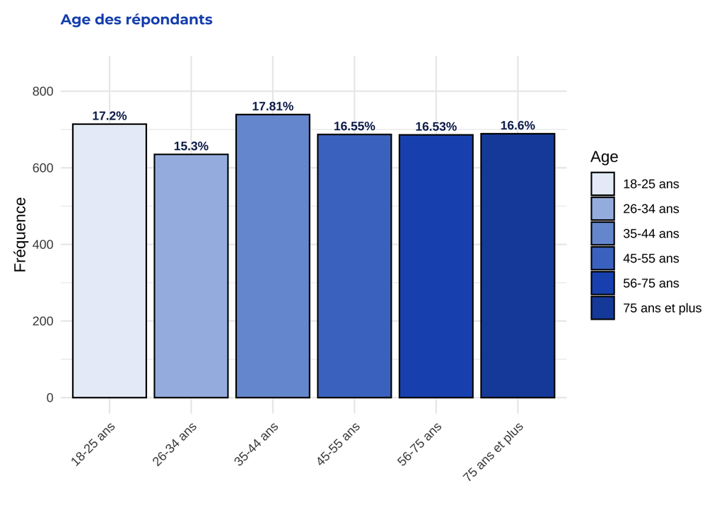

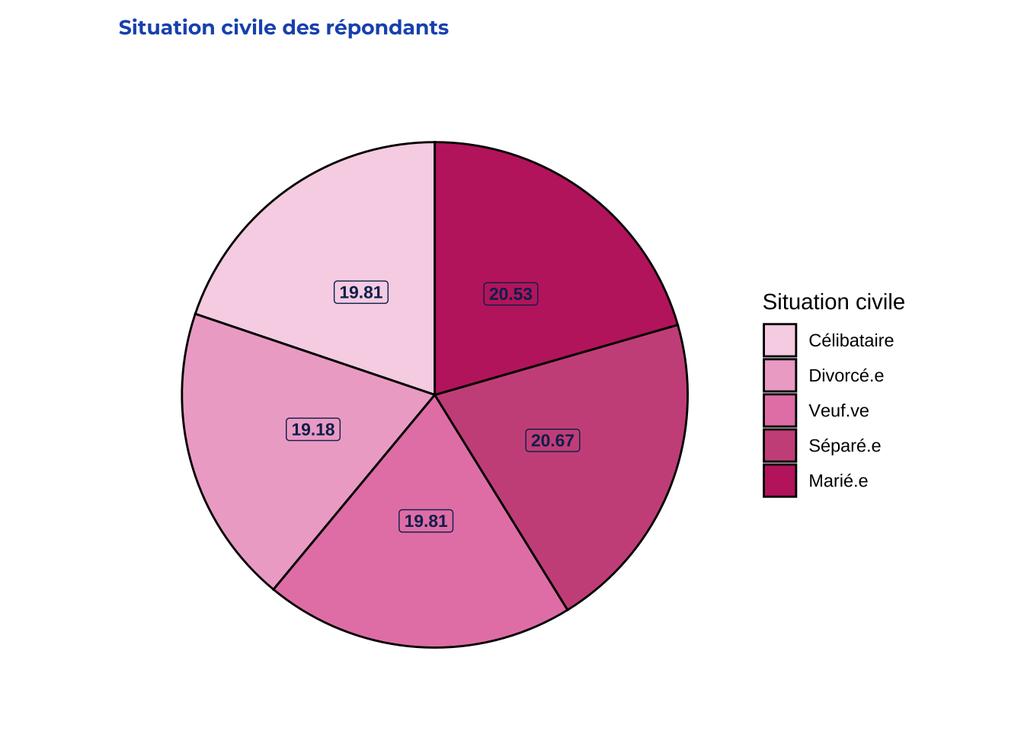

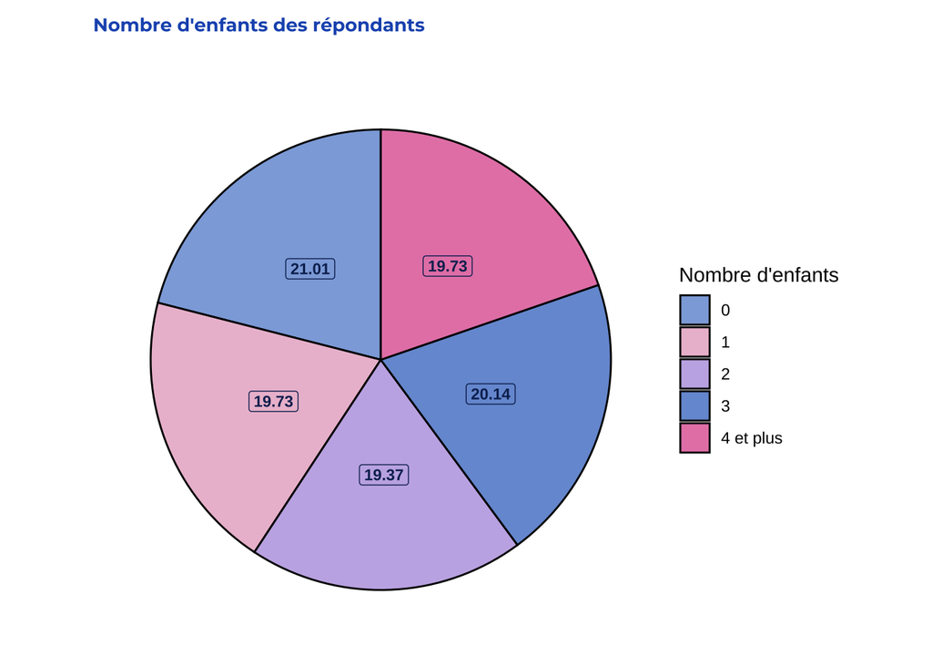

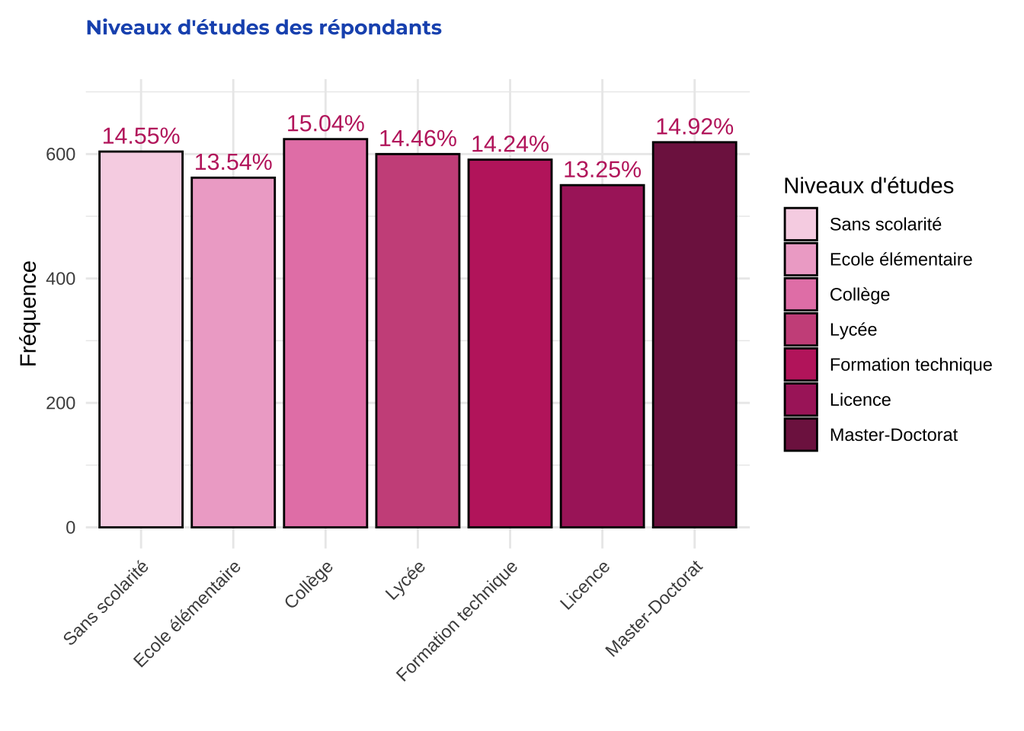

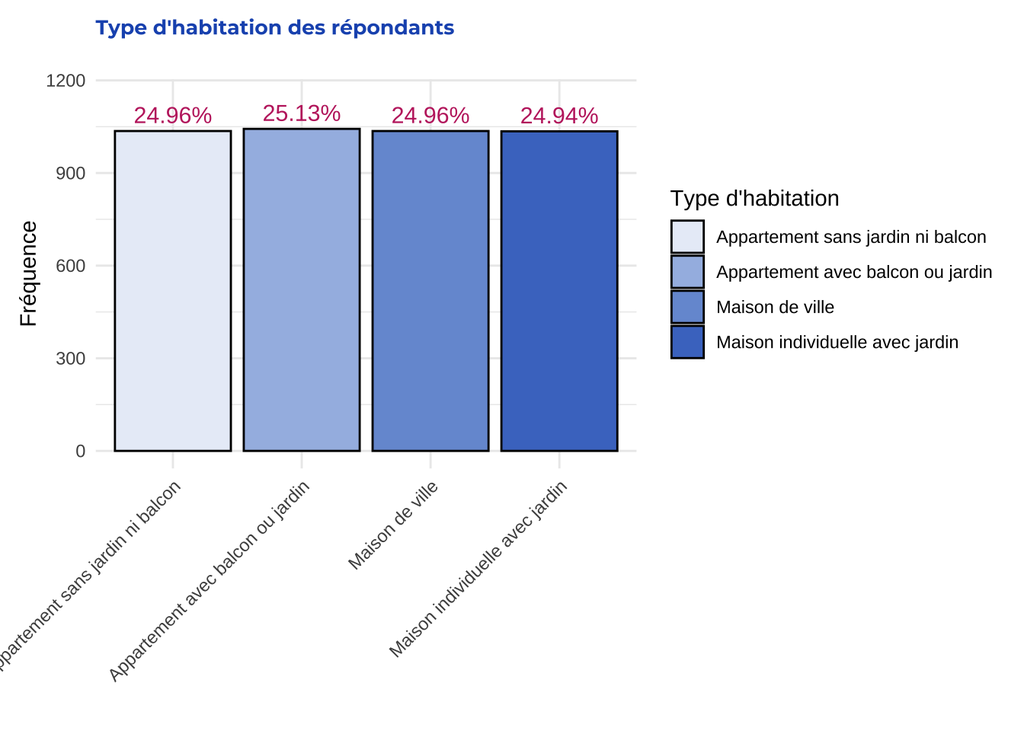

### Niveaux de bien-être et perception de nature

Les tableaux ci-dessous présentent les niveaux de bien-être et de perception de nature des habitants de Benev-ville.

La moyenne pour notre échantillon national apparaît entre parenthèses lorsqu’elle est significativement différente de la moyenne des habitants de Benev-ville.

## Niveaux de bien-être

Nous avons interrogé les résidents sur leur niveau de bien-être au cours de la dernière semaine dans leur lieu de résidence. L’échelle de bien-être que nous utilisons permet d’obtenir une note de bien-être global et de distinguer les facettes suivantes : le bien-être psychologique, physique, lié à l’environnement (perception que l’on vit dans un environnement sain et satisfaisant) et lié aux ressources (satisfaction quant à notre capacité à nous déplacer, à pratiquer des loisirs, à accéder aux informations). Plus les notes sont élevées, plus les résidents ont des niveaux de bien-être élevés.

|  | Critère | Note moyenne |
| --- | --- | --- |
| 1 | Bien-être global | 2.99 (3.51) |
| 2 | Bien-être psychologique | 2.99 (3.3) |
| 3 | Bien-être environnemental | 3 (3.87) |
| 4 | Bien-être physique | 3.01 (3.84) |
| 5 | Bien-être ressources | 2.97 (3.37) |

Entre parenthèses sont présentées les moyennes à l’échelle nationale. La note minimale théorique est 1 et la note maximale théorique est 5.

## Perception de nature autour du lieu de résidence

Nous avons interrogé les résidents sur les types d’espaces verts et de nature à proximité de leur lieu de résidence (qu’ils voient de chez eux ou auquel ils ont accès en moins de 15 min à pied). Ces types d’espaces verts sont catégorisés en trois dimensions : la nature de proximité comme les parterres de fleurs et les toits végétalisés ; la nature domestiquée comme les parcs et jardins publics et la nature non-domestiquée comme les bois, les prairies. Plus les notes sont élevées, plus les résidents ont accès à ces types de nature autour de leur lieu de résidence.

|  | Critère | Note moyenne |
| --- | --- | --- |
| 1 | Perception de nature globale | 3 (2.54) |
| 2 | Perception de nature non-domestiquée | 3 (2.68) |
| 3 | Perception de nature domestiquée | 2.99 (3.22) |
| 4 | Perception de nature de proximité | 3 (2.02) |
| 5 | Fréquence d'exposition à la nature | 2.99 (2.92) |
| 6 | Perception de biodiversité | 3.01 (3.38) |

## Caractéristiques des lieux de nature autour du lieu de résidence

Nous avons interrogé les résidents sur leur satisfaction concernant certaines caractéristiques des environnements naturels à proximité de leur lieu de résidence. Plus les notes sont élevées, plus les résidents sont satisfaits de ces caractéristiques.

|  | Critère | Note moyenne |
| --- | --- | --- |
| 1 | La sécurité | 3.17 (3.48) |
| 2 | La propreté | 3.17 (3.42) |
| 3 | L’esthétique, la beauté des lieux | 3.24 (3.66) |
| 4 | Le coût (coût d’accès, d’entretien) | 3.25 (3.61) |
| 5 | Les horaires d’ouverture | 3.3 (3.74) |
| 6 | La signalétique | 3.16 (3.47) |
| 7 | La facilité d’accès | 3.31 (3.84) |
| 8 | Les espaces de mobilité | 3.22 (3.54) |
| 9 | Les espaces ou installations permettant le repos | 3.19 (3.49) |
| 10 | Les espaces ou installations permettant le loisir | 3.2 (3.45) |

Entre parenthèses sont présentées les moyennes à l’échelle nationale. La note minimale théorique est 1 et la note maximale théorique est 5.

## Activités dans la nature

Nous avons interrogé les résidents sur la fréquence à laquelle ils effectuaient certaines activités dans la nature à proximité de le lieu de résidence. Ces activités sont regroupées en activités sociales et/ou calmes et activités sportives. Plus les notes sont élevées, plus les résidents effectuent fréquemment ces activités dans les lieux de nature autour de chez eux.

|  | Critère | Note moyenne |
| --- | --- | --- |
| 1 | Fréquence d'activités globales | 2.99 (2.15) |
| 2 | Fréquence d'activités sociales et/ou calmes | 2.99 (2.23) |
| 3 | Fréquence d'activités sportives | 2.97 (1.85) |

Entre parenthèses sont présentées les moyennes à l’échelle nationale. La note minimale théorique est 1 et la note maximale théorique est 5.

### Exemple d’analyse approfondie : Niveaux de bien-être et perception de nature en fonction des caractéristiques de la population

|  | Genre | Critère Bien-Être Global | Différence Estimée | p-value |
| --- | --- | --- | --- | --- |
| 1 | Femme | 2.99 | -0.01 | 0.529 |
| 2 | Homme | 2.99 | -0.01 | 0.529 |

|  | Genre | Critère Nature Global | Différence Estimée | p-value |
| --- | --- | --- | --- | --- |
| 1 | Femme | 2.99 | -0.01 | 0.326 |
| 2 | Homme | 3 | -0.01 | 0.326 |

## Données cartographiques de Benev-ville

Choisir l’indicateur à visualiser dans la carte :

Cacher les infos en dessous des couleurs

**Cartographie générale**

N.B. Le ratio bien-être / nature est calculé à partir du déficit moyen de bien-être et du déficit moyen de perception de nature dans chaque zone. Chaque déficit correspond à l’écart entre le score observé et le score maximal théorique de 5. Le produit de ces deux déficits est ensuite divisé par 16 afin d’obtenir un score normalisé compris entre 0 et 1. Plus ce score est élevé, plus la zone cumule un faible niveau de bien-être et un faible niveau de nature perçue, ce qui en fait une zone prioritaire de revégétalisation.  
Le ratio n’est pas calculé individu par individu mais à partir des moyennes observées dans chaque zone de résidence. On estime d’abord le niveau moyen de bien-être et de perception de nature dans la zone, puis on calcule les déficits correspondants, avant de construire le ratio final. Ainsi, le score reflète la situation moyenne de la zone elle-même.

## Commentaires concernant la ville

## Conclusion

On notera que les perceptions de présence de la nature sont **variables**, et qu’elles reflètent la présence effective du bois au sud, et du Parc de la Haute Ile au Nord. Les répondants à proximité de ces deux espaces de nature, de même que ceux du parc des mares rapportent des **perceptions de nature et de bien-être plus élevées que ceux situés dans d’autres zones**. Ils rapportent également des niveaux d’activités physiques plus élevés, tout comme ceux habitant près d’équipements sportifs – Stade Mimoun -. Si l’aménagement de nouveaux parcs, en zone urbaine dense, n’est pas envisageable, celui de **promenades plantées** liant ces espaces peut constituer une piste à envisager.